# My First markdown document

Grace Durant

2/7/2022

Add text here. Use as much or as little as you like.

New text appears here in a separate paragraph.

Grace Durant  
361 Pearl St  
Burlington, VT

Use 2 or more spaces at the end of a single-spaced line.

# basic text formatting

italic *text* like this

bold **text** like this

subscript<sub>text</sub> like this

superscript<sup>text</sup> like this

strikethrough text like this

# Lists

## Unordered lists

- Item 1
- Item 2
  - Item 2a
  - Item 2b
1. Item 1
2. Item 2
3. Item 3
   - Item 3a
   - Item 3b

# Fencing

In line fencing with a back tick `to show anything in plain text with *no* formatting` which can be useful for many things.

In line execution of r inside the back ticks by inserting r as the first element 6.1415927

In line execution of r inside the back ticks by inserting r as the first element `3 + pi`

3 back ticks for a whole section of plain text

```
Everything in here as plaintext.
Even single lines.

Useful especially when showing other coding intructions
```

# Block quotes with `>`

> To be or not to be, that is the question whether tis nobler…

# Spacer line with 3 or more underscores

Adds a line between text…

# Links

https://example.com

[linked phrase](http://example.com)

# Images

[figure not shown]

alt text

`[alt text](figures/img.png)`

# Table

| First Header | Second Header |
| --- | --- |
| Content Cell | Content Cell |
| Content Cell | *formatted text* |

# LaTeX code for equations

We set off equations with `$` for brackets.

## In-line equations

These equations such as $a = 3 + 4$ will appear inside of a single line of text.

These equations such as
$$a = 3 + 4$$
will appear in a separate line of text.

## Supscripts

$$H_0 = Z_{a + b}$$

## Superscripts

$$S = cA^z$$

Elements can be coupled and nested

$$S = cA^z_1 + z_{2 + x}$$

## Fractions and Greek symbols

$$\alpha = \frac{\beta}{\delta + \gamma_x}$$

## Summation signs

$$Z = \sum_{i=1}^X{k}$$

## Escape the backslash with a custom term

$$\backslash \alpha \le b \backslash$$

## Rendering plaintext in a LaTeX equation

$$P(Occurance of Species A) = Z$$

$$P(\mbox{Occurance of Species A}) = Z$$

```
##  [1] 0.87152382 0.55347863 0.97641877 0.08508841 0.55099975 0.16394103
##  [7] 0.01062489 0.02106313 0.69932335 0.29015952
```

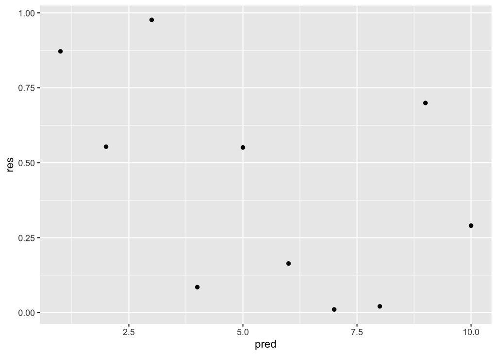

Now back to wirting text in our markdown document, including LaTeX equations if we need them such as $a + b$ inserted in the middle of my sentence